# Crizer et al. (2024): Analysis of PFAS Hepatic Clearance Data

David Crizer, Marci G. Smeltz, John F. Wambaugh, and Barbara A. Wetmore

2024-09-18

*Please send questions to wambaugh.john@epa.gov*

from “Category-Based Toxicokinetic Evaluations of Data-Poor Per and Polyfluoroalkyl Substances (PFAS) by Gas Chromatography Coupled with Mass Spectrometry”

Anna Kreutz, Matthew Scott Clifton, W. Matthew Henderson, Marci G. Smeltz, John F. Wambaugh, and Barbara A. Wetmore

## Abstract

Concern over per- and polyfluoroalkyl substances (PFAS) has increased significantly as more is learned about their widespread environmental presence, persistence, and bioaccumulative potential. The limited measurement, monitoring, toxicokinetic (TK), and toxicologic data currently available is inadequate to inform risk evaluations across this diverse domain. In this study, 73 PFAS were selected for *in vitro* TK evaluation to expand our knowledge across lesser studied PFAS that include alcohol, amide, and acrylate functional groups. Targeted analytical methods were developed using gas chromatography coupled with tandem mass spectrometry (GC-MS/MS); ultracentrifugation was used to measure human plasma protein binding and human hepatocyte suspensions were used in a substrate depletion approach to measure in vitro clearance (Clint). Method development was successful in plasma for 43 PFAS, with fraction unbound in plasma ($f_{up}$) values ranging from 0.004 for 1,6-dibromododecafluorohexane and 1 for 2-aminohexafluoropropan-2-ol, With a median $f_{up}$ of 0.09 (i.e., 91% bound), these PFAS are highly bound, but exhibit 10-fold lower binding than that recently reported for legacy perfluoroalkyl acids (Smeltz et al., 2022). Physico-chemical property trends analyses revealed that increased binding was associated with increases in mass, van der Waals volumes, and values of Log Pow and Log D at pH 7.4. Thirty of the PFAS evaluated in the hepatocyte assay showed abiotic loss, with many exceeding 60% loss within 60 min of media addition. Metabolic clearance was noted for 11 of the 13 successfully evaluated, with rates up to 49.9 l/min/million cells for 1H,1H,10H,10H-Perfluorodecane-1,10-diol. The Chemical Transformation Simulator revealed potential metabolites and other transformation products to consider during *in vitro* assay data interpretation. This integration of quantitative analytic methods with *in vitro* toxicokinetics has provided critical learnings as New Approach Methods are considered to evaluate PFAS for which volatility, metabolism, and other routes of transformation are likely to modulate their environmental fate.

## HTTK Version

This vignette was created with **httk** v2.3.0. Although we attempt to maintain backward compatibility, if you encounter issues with the latest release of **httk** and cannot easily address the changes, historical versions of httk are available from: https://cran.r-project.org/src/contrib/Archive/httk/

## Prepare for session

```r
knitr::opts_chunk$set(collapse = TRUE, comment = '#>')
options(rmarkdown.html_vignette.check_title = FALSE)
```

### Clear the memory

It is a bad idea to let variables and other information from previous R sessions float around, so we first remove everything in the R memory.

```r
rm(list=ls())
```

### eval = execute.vignette

```r
# Set whether or not the following chunks will be executed (run):
execute.vignette <- TRUE
```

### Load the relevant libraries

If you get the message “Error in library(X) : there is no package called ‘X’” then you will need to install that package:

From the R command prompt:

install.packages(“X”)

Or, if using RStudio, look for ‘Install Packages’ under ‘Tools’ tab.

```r
#
#
# Setup
#
#
library(ggplot2)
library(httk)
library(grid)
library(scales)
library(viridis)
library(ggpubr)
library(readxl)

LOC.WD <- "c:/users/jwambaug/"
PFAS.MODEL.USED <- "sumclearancespfas"
NONPFAS.MODEL.USED <- "sumclearances"
```

Set the sizes of the labels and points in the figure (these settings impact the PNG differently than the figure within RStudio):

```r
FONT.SIZE <- 24
POINT.SIZE <- 4
```

### Function to format scientific notation

From https://stackoverflow.com/questions/10762287/how-can-i-format-axis-labels-with-exponents-with-ggplot2-and-scales

```r
scientific_10 <- function(x) {
  out <- gsub("1e", "10^", scientific_format()(x))
  out <- gsub("\\+","",out)
  out <- gsub("10\\^01","10",out)
  out <- parse(text=gsub("10\\^00","1",out))
}
```

# Analysis of Crizer et al. (2023) $Cl_{int}$ data

## Remove Rat-specific HTTK data:

```r
chem.physical_and_invitro.data$Rat.Clint <- NA
chem.physical_and_invitro.data$Rat.Funbound.plasma <- NA
```

```r
new.pfas <- get_2023pfasinfo(info="dtxsid",
                                      model=PFAS.MODEL.USED,
                                      suppress.messages=TRUE)
clint.fup <- subset(chem.physical_and_invitro.data,
                    !is.na(Human.Funbound.plasma) &
                    !is.na(Human.Clint) &
                    (regexpr("PFAS",Chemical.Class)==-1 |
                    DTXSID %in% new.pfas))
clint.fup$Human.Clint <- sapply(clint.fup$Human.Clint,
                                function(x) as.numeric(strsplit(x,",")[[1]][1]))
clint.fup$Human.Funbound.plasma <- sapply(clint.fup$Human.Funbound.plasma,
                                function(x) as.numeric(strsplit(x,",")[[1]][1]))
clint.fup[clint.fup$Chemical.Class=="","Chemical.Class"] <- "Non-PFAS"
clint.fup[clint.fup$Chemical.Class=="PFAS","Chemical.Class"] <- "Newly Measured PFAS"
```

[figure not shown]

```r
fig.clint.fup  <- ggplot(data=clint.fup) +
  geom_point(aes(
    x=Human.Funbound.plasma,
    y=Human.Clint,
    colour=Chemical.Class,
    shape=Chemical.Class),
    size=POINT.SIZE) +
  ylab(expression(italic("In Vitro")~"Measured Cl"[int]~"("*mu*"L/min/10"^'6'~"hepatocytes)")) +
  xlab(expression(italic("In Vitro")~"Measured f"[up])) +
  scale_x_log10(label=scientific_10)+
  scale_y_log10(label=scientific_10)+
  theme_bw()  +
  theme( text  = element_text(size=FONT.SIZE))+
        scale_color_viridis(discrete=2)

print(fig.clint.fup)
```

[figure not shown]

```r
fig.fup.hist <- ggplot(data=clint.fup) +
  geom_histogram(aes(
    x=Human.Funbound.plasma,
    colour=Chemical.Class,
    fill=Chemical.Class)) +
  xlab(expression(italic("In Vitro")~"Measured f"[up])) +
  scale_x_log10(label=scientific_10)+
  theme_bw()  +
  theme( text  = element_text(size=FONT.SIZE))+
        scale_fill_viridis(discrete=2)+
        scale_color_viridis(discrete=2)

print(fig.fup.hist)
```

[figure not shown]

```r
fig.clint.hist <- ggplot(data=clint.fup) +
  geom_histogram(aes(
    x=Human.Clint+10^-5,
    colour=Chemical.Class,
    fill=Chemical.Class)) +
  xlab(expression(italic("In Vitro")~"Measured Cl"[int]~"("*mu*"L/min/10"^'6'~"hepatocytes)")) +
  scale_x_log10(label=scientific_10)+
  theme_bw()  +
  theme( text  = element_text(size=FONT.SIZE))+
        scale_fill_viridis(discrete=2)+
        scale_color_viridis(discrete=2)+
  coord_flip()

print(fig.clint.hist)
```

```
#> Warning: Removed 10 rows containing non-finite outside the scale range
#> (`stat_bin()`).
```

[figure not shown]

```r
fig.henry.hist <- ggplot(data=clint.fup) +
  geom_histogram(aes(
    x=10^logHenry,
    colour=Chemical.Class,
    fill=Chemical.Class)) +
  xlab(expression("Henry's Law Constant (Atm.-m"^"3"*"/mole)")) +
  scale_x_log10(label=scientific_10)+
  geom_vline(xintercept =10^-4.5,linetype="dashed",color="blue")+
  theme_bw()  +
  theme( text  = element_text(size=FONT.SIZE))+
        scale_fill_viridis(discrete=2)+
        scale_color_viridis(discrete=2)

print(fig.henry.hist)
```

[figure not shown]

```r
ggarrange(fig.clint.fup, fig.clint.hist, fig.fup.hist, fig.henry.hist,
          labels = c("A", "B", "C", "D"),
          ncol = 2, nrow = 2,
          common.legend = TRUE, legend = "bottom")
```

```r
tiff(file = paste0(LOC.WD,"Fig_NewClintFup.tiff"),
         height = 5*200, width = 5*200, compression = "lzw")
ggarrange(fig.clint.fup, fig.clint.hist, fig.fup.hist, fig.henry.hist,
          labels = c("A", "B", "C", "D"),
          ncol = 2, nrow = 2,
          common.legend = TRUE, legend = "bottom")
dev.off()
```

## Compare against in vivo clearance data:

```r
cl.table <- httk::pfas.clearance

for (this.chem in unique(cl.table$DTXSID))
  if (this.chem %in% get_2023pfasinfo(info="dtxsid",
                                      model=PFAS.MODEL.USED,
                                      suppress.messages=TRUE))
  {
    chem.subset <- subset(cl.table, DTXSID==this.chem)
    for (this.species in unique(cl.table$Species))
    {
      # Css in units of mg/L for 1 mg/kg/day
      out <- calc_analytic_css(dtxsid=this.chem,
                               species=this.species,
                               model=PFAS.MODEL.USED,
                               output.units="mg/L",
                               parameterize.args=list(default.to.human=TRUE,
                                                      class.exclude=FALSE),
                               suppress.messages=TRUE)
      if (any(cl.table$DTXSID==this.chem &
               cl.table$Species==this.species))
        cl.table[cl.table$DTXSID==this.chem &
               cl.table$Species==this.species,
               "HTTK.Cltot.Lphpkgbw"] <-
        1/out/24
      else {
        new.row <- cl.table[1,]
        new.row[] <- NA
        new.row[,"DTXSID"] <- this.chem
        new.row[,"Species"] <- this.species
        new.row[,"Sex"] <- "Female"
        new.row[,"HTTK.Cltot.Lphpkgbw"] <-
        1/out/24
        cl.table <- rbind(cl.table,new.row)
        new.row[,"Sex"] <- "Male"
        cl.table <- rbind(cl.table,new.row)
      }
    }
  }
```

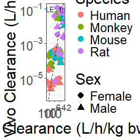

```r
RMSLE <- function(tab,colx,coly)
{
    return(signif(mean(log10(tab[,colx]/tab[,coly])^2,na.rm=TRUE)^(1/2),3))
}

fig.clhttk.invivo  <- ggplot(data=cl.table) +
  geom_point(aes(
    x=HTTK.Cltot.Lphpkgbw,
    y=ClLphpkgbw,
    color=Species,
    shape=Sex),
    size=POINT.SIZE) +
  geom_abline(slope=1,intercept=0,linetype="dashed")+
#  geom_line(aes(x=logP,y=logPfit1),color="black") +
#  geom_line(aes(x=logP,y=logPfit2),color="blue",linetype = "dashed") +
  ylab("In Vivo Clearance (L/h/kg bw)") +
  xlab("HTTK Clearance (L/h/kg bw)") +
  scale_x_log10(label=scientific_10)+
  scale_y_log10(label=scientific_10)+
  theme_bw()  +
  theme( text  = element_text(size=FONT.SIZE))+
  annotate("text", x = 10^-6, y = 10^-1,
           label = paste("RMSLE:",
                         RMSLE(cl.table,"HTTK.Cltot.Lphpkgbw","ClLphpkgbw")))

print(fig.clhttk.invivo)
```

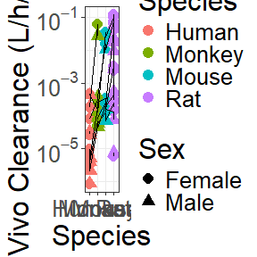

```r
fig.clspecies.invivo  <- ggplot(data=cl.table) +
  geom_point(aes(
    x=Species,
    y=ClLphpkgbw,
    color=Species,
    shape=Sex),
    size=POINT.SIZE) +
  geom_line(aes(x=Species,
              y=ClLphpkgbw,
              group = DTXSID)) +
#  geom_line(aes(x=logP,y=logPfit1),color="black") +
#  geom_line(aes(x=logP,y=logPfit2),color="blue",linetype = "dashed") +
  ylab("In Vivo Clearance (L/h/kg bw)") +
  xlab("Species") +
  scale_y_log10(label=scientific_10)+
  theme_bw()  +
  theme( text  = element_text(size=FONT.SIZE))

print(fig.clspecies.invivo)
```

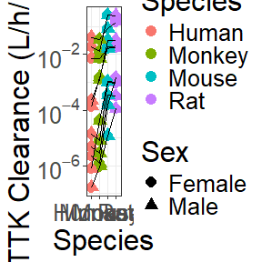

```r
fig.clspecies.httk  <- ggplot(data=cl.table) +
  geom_point(aes(
    x=Species,
    y=HTTK.Cltot.Lphpkgbw,
    color=Species,
    shape=Sex),
    size=POINT.SIZE) +
#  geom_segment(color="#69b3a2",
#                  aes(
#                    x=Species,
#                    y=HTTK.Cltot.Lphpkgbw,
#                    xend = c(tail(Species, n = -1), NA),
#                    yend = c(tail(HTTK.Cltot.Lphpkgbw, n = -1), NA)
#                  ))+
geom_line(aes(x=Species,
              y=HTTK.Cltot.Lphpkgbw,
              group = DTXSID)) +
ylab("HTTK Clearance (L/h/kg bw)") +
  xlab("Species") +
  scale_y_log10(label=scientific_10)+
  theme_bw()  +
  theme( text  = element_text(size=FONT.SIZE))

print(fig.clspecies.httk)
```

```r
for (this.chem in unique(cl.table$DTXSID))
  {
    chem.subset <- subset(cl.table, DTXSID==this.chem)
    for (this.species in unique(cl.table$Species))
    {
      p <- try(parameterize_pfas1comp(dtxsid=this.chem,
                                  species=this.species,
                                  suppress.messages=TRUE))
      # Clearance in units of L/h/kgBW
      if(!is(p, "try-error"))
        cl.table[cl.table$DTXSID==this.chem &
               cl.table$Species==this.species,
               "MachineLearning.Cltot.Lphpkgbw"] <- p$kelim*p$Vd
    }
  }
```

```
#> Error in parameterize_pfas1comp(dtxsid = this.chem, species = this.species,  :
#>   Chemical outside domain of applicability estimated from training set.
```

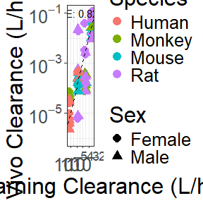

```r
fig.clml.invivo  <- ggplot(data=cl.table) +
  geom_jitter(aes(
    x=MachineLearning.Cltot.Lphpkgbw,
    y=ClLphpkgbw,
    color=Species,
    shape=Sex),
    size=POINT.SIZE,
    height=0,width=0.1) +
  geom_abline(slope=1,intercept=0,linetype="dashed")+
#  geom_line(aes(x=logP,y=logPfit1),color="black") +
#  geom_line(aes(x=logP,y=logPfit2),color="blue",linetype = "dashed") +
  ylab("In Vivo Clearance (L/h/kg bw)") +
  xlab("Machine Learning Clearance (L/h/kg bw)") +
  scale_x_log10(label=scientific_10)+
  scale_y_log10(label=scientific_10)+
  theme_bw()  +
  theme( text  = element_text(size=FONT.SIZE))+
  annotate("text", x = 10^-5, y = 10^-1,
           label = paste("RMSLE:",
                         RMSLE(cl.table,
                               "MachineLearning.Cltot.Lphpkgbw",
                               "ClLphpkgbw")))

print(fig.clml.invivo)
```

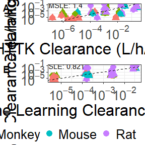

```r
ggarrange(fig.clhttk.invivo, fig.clml.invivo,
          labels = c("A", "B"),
          ncol = 1, nrow = 2,
          common.legend = TRUE, legend = "bottom")
```

```r
tiff(file = paste0(LOC.WD,"Fig_PFASClearanceEval.tiff"),
         height = 5*200, width = 3*200, compression = "lzw")
ggarrange(fig.clhttk.invivo, fig.clml.invivo,
          labels = c("A", "B"),
          ncol = 1, nrow = 2,
          common.legend = TRUE, legend = "top")
dev.off()
```

```r
cl.table <- as.data.frame(cl.table)
for (this.sex in c("Female","Male"))
{
  human.data <- subset(cl.table, Species=="Human" &
                            Sex==this.sex)
  for (this.species in unique(cl.table$Species))
  if (this.species != "Human")
  {
    species.data <- subset(cl.table, Species==this.species &
                                     Sex==this.sex)
    for (this.chem in union(human.data$DTXSID, species.data$DTXSID))
    {
      cl.table.index <- cl.table$Sex==this.sex &
               cl.table$Species==this.species &
               cl.table$DTXSID==this.chem
      human.table.index <- human.data$Sex==this.sex &
               human.data$DTXSID==this.chem
      species.table.index <- species.data$Sex==this.sex &
               species.data$DTXSID==this.chem
      if (any(human.table.index) & any(species.table.index))
      {
        cl.table[cl.table.index, "TK.Ratio.InVivo"] <-
        signif(species.data[species.table.index, "ClLphpkgbw"] /
        human.data[human.table.index, "ClLphpkgbw"], 4)

        cl.table[cl.table.index, "TK.Ratio.HTTK"] <-
        signif(species.data[species.table.index, "HTTK.Cltot.Lphpkgbw"] /
        human.data[human.table.index, "HTTK.Cltot.Lphpkgbw"], 4)

        cl.table[cl.table.index, "TK.Ratio.ML"] <-
        signif(species.data[species.table.index, "MachineLearning.Cltot.Lphpkgbw"] /
        human.data[human.table.index, "MachineLearning.Cltot.Lphpkgbw"], 4)
      }
    }
  }
}
```

```r
huh.data <- as.data.frame(read_excel(paste0(LOC.WD,"Huh-2011-HumanCL.xlsx")))
huh.data$Human.CL.Lphpkg <- as.numeric(huh.data[,4])*60/1000
huh.data$Rat.CL.Lphpkg <- as.numeric(huh.data$a)*(0.25)^as.numeric(huh.data$b)*60/1000

httk.chem.list <- get_cheminfo(model=PFAS.MODEL.USED, info="DTXSID")
for (this.chem in huh.data[,"DTXSID"])
  if (!is.na(this.chem))
  {
  this.row <- which(huh.data[,"DTXSID"]==this.chem)
  new.row <- cl.table[1,]
  new.row[1,] <- NA
  new.row[1, "DTXSID"] <- huh.data[this.row, "DTXSID"]
  new.row[1, "Species"] <- "Rat"
  new.row[1, "Sex"] <- "Female"
  new.row[1, "ClLphpkgbw"] <- huh.data[this.row, "Human.CL.Lphpkg"]

  new.row[1, "TK.Ratio.InVivo"] <- huh.data[this.row, "Rat.CL.Lphpkg"] /
    huh.data[this.row, "Human.CL.Lphpkg"]
  if (this.chem %in% httk.chem.list)
    if (!(this.chem %in% new.pfas) |
        this.chem %in% dawson2023$DTXSID)
  {
    print(this.chem)
    human.css <- calc_analytic_css(dtxsid = this.chem,
                               model=ifelse(this.chem %in% new.pfas,
                                            PFAS.MODEL.USED,
                                            NONPFAS.MODEL.USED),
                               output.units="mg/L",
                               species="Human",
                               suppress.messages=TRUE)
    new.row[1, "HTTK.Cltot.Lphpkgbw"] <-
        1/human.css/24
    rat.css <- calc_analytic_css(dtxsid = this.chem,
                               model=ifelse(this.chem %in% new.pfas,
                                            PFAS.MODEL.USED,
                                            NONPFAS.MODEL.USED),
                               output.units="mg/L",
                               species="Rat",
                               parameterize.args=list(default.to.human=TRUE),
                               suppress.messages=TRUE)
    new.row[1, "TK.Ratio.HTTK"] <- signif(human.css/rat.css,4)
    cl.table <- rbind(cl.table,new.row)
  }
  }
```

```
#> [1] "DTXSID4020822"
#> [1] "DTXSID6021117"
#> [1] "DTXSID6022680"
#> [1] "DTXSID7046627"
#> [1] "DTXSID0020232"
#> [1] "DTXSID2022759"
#> [1] "DTXSID0022808"
#> [1] "DTXSID8022824"
#> [1] "DTXSID7020348"
#> [1] "DTXSID4020406"
#> [1] "DTXSID9022940"
#> [1] "DTXSID4023042"
#> [1] "DTXSID6020648"
#> [1] "DTXSID4034150"
#> [1] "DTXSID3037125"
```

[output cut: 19 more lines]

```r
cl.table$Class <- "PFAS"
cl.table[!(cl.table$DTXSID %in% new.pfas), "Class"] <- "Non-PFAS"
cl.table$Class <- factor(cl.table$Class, levels=c("PFAS","Non-PFAS"))
```

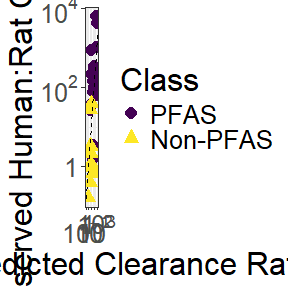

```r
fig.ratio.httk  <- ggplot(data=subset(cl.table, Species=="Rat")) +
  geom_point(aes(
    x=TK.Ratio.HTTK,
    y=TK.Ratio.InVivo,
    color=Class,
    shape=Class),
    size=POINT.SIZE) +
  geom_abline(slope=1,intercept=0,linetype="dashed")+
#  geom_line(aes(x=logP,y=logPfit1),color="black") +
#  geom_line(aes(x=logP,y=logPfit2),color="blue",linetype = "dashed") +
  ylab("In Vivo Observed Human:Rat Clearance Ratio") +
  xlab("HTTK Predicted Clearance Ratio") +
  scale_x_log10(label=scientific_10)+
  scale_y_log10(label=scientific_10)+
  theme_bw()  +
  theme( text  = element_text(size=FONT.SIZE)) +
  scale_color_viridis(discrete=2)

print(fig.ratio.httk)
```

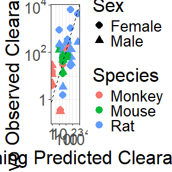

```r
  ggsave(paste0(LOC.WD,
    "Fig_rat_cl_ratio.tiff"),
         height =11, width =12, dpi = 300)
fig.ratio.ml  <- ggplot(data=subset(cl.table, Species!="Human")) +
  geom_point(aes(
    x=TK.Ratio.ML,
    y=TK.Ratio.InVivo,
    color=Species,
    shape=Sex),
    size=POINT.SIZE) +
  geom_abline(slope=1,intercept=0,linetype="dashed")+
#  geom_line(aes(x=logP,y=logPfit1),color="black") +
#  geom_line(aes(x=logP,y=logPfit2),color="blue",linetype = "dashed") +
  ylab("In Vivo Observed Clearance Ratio") +
  xlab("Machine Learning Predicted Clearance Ratio") +
  scale_x_log10(label=scientific_10)+
  scale_y_log10(label=scientific_10)+
  theme_bw()  +
  theme( text  = element_text(size=FONT.SIZE))

print(fig.ratio.ml)
```

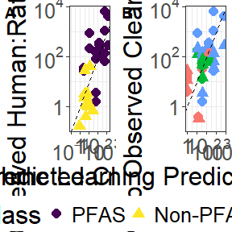

```r
  ggsave(paste0(LOC.WD,
    "Fig_ml_cl_ratio.tiff"),
         height = 11, width = 12, dpi = 300)
ggarrange(fig.ratio.httk, fig.ratio.ml,
          labels = c("A", "B"),
          ncol = 2, nrow = 1,
          common.legend = TRUE, legend = "bottom")
```

```r
tiff(file = paste0(LOC.WD,"Fig_PFASRatioEval.tiff"),
         height = 3*200, width = 5*200, compression = "lzw")
ggarrange(fig.ratio.httk, fig.ratio.ml,
          labels = c("A", "B"),
          ncol = 2, nrow = 1,
          common.legend = TRUE, legend = "top")
dev.off()
```

```r
firstpass.table <- NULL
for (this.chem in get_2023pfasinfo(info="dtxsid", suppress.messages=TRUE,
                                   model=PFAS.MODEL.USED))
{
      params <- parameterize_sumclearances(dtxsid=this.chem,
                                         suppress.messages=TRUE,
                                         class.exclude=FALSE)
      params2 <- parameterize_schmitt(dtxsid=this.chem,
                                      suppress.messages=TRUE,
                                      class.exclude=FALSE)
      ion <- calc_ionization(
        pH=7.4,
        pKa_Donor=params2[["pKa_Donor"]],
        pKa_Accept=params2[["pKa_Accept"]])
      fraction_neutral <- ion$fraction_neutral
      if (fraction_neutral < 0.5) params[['Rblood2plasma']] <- 0.5
      else params[['Rblood2plasma']] <- 20
  params[["Clmetabolismc"]] <- calc_hep_clearance(parameters=params,
          hepatic.model='unscaled',
          suppress.messages=TRUE)#L/h/kg body weight
  this.row <- data.frame(DTXSID=this.chem,
                         Fsystemic=calc_hep_bioavailability(
                           parameters=params)
  )
  firstpass.table <- rbind(firstpass.table, this.row)
}
```

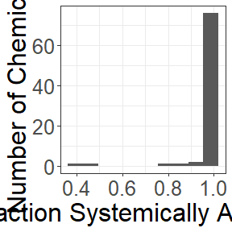

```r
fig.firstpass  <- ggplot(data=firstpass.table) +
  geom_histogram(aes(
    x=Fsystemic),bins=10) +
  ylab("Number of Chemicals") +
  xlab("Fraction Systemically Available") +
  theme_bw()  +
  theme( text  = element_text(size=FONT.SIZE))

print(fig.firstpass)
```

# Evaluate Ratio Blood:Plasma Predictions

```r
rb2p.table <- subset(chem.physical_and_invitro.data,
                     Human.Rblood2plasma.Reference %in% "Poothong 2017")
rb2p.table <- rb2p.table[,colnames(rb2p.table) %in%
                                     c("Compound","DTXSID",
                                       "Human.Rblood2plasma"
                                     )]
for (this.chem in rb2p.table$DTXSID)
{
  if (this.chem %in% get_2023pfasinfo(info="dtxsid", suppress.messages=TRUE,
                                   model=PFAS.MODEL.USED))
  {
    rb2p.table[rb2p.table$DTXSID==this.chem,"HTTK.Rb2p"] <-
      calc_rblood2plasma(dtxsid=this.chem,
                         class.exclude=FALSE)
  }
  p <- try(parameterize_pfas1comp(dtxsid=this.chem))
  if(!is(p, "try-error"))
    rb2p.table[rb2p.table$DTXSID==this.chem,"ML.Rb2p"] <-
    p$Rblood2plasma
}
```

```
#> Error in parameterize_pfas1comp(dtxsid = this.chem) :
#>   Chemical outside domain of applicability estimated from training set.
#> Error in parameterize_pfas1comp(dtxsid = this.chem) :
#>   Chemical outside domain of applicability estimated from training set.
```

# Evaluate Membrane Affinity Predictions

```r
logma.table <- subset(chem.physical_and_invitro.data,
                     logMA.Reference %in% "Droge 2019")
logma.table <- logma.table[,colnames(logma.table) %in%
                                     c("Compound","DTXSID",
                                       "logMA"
                                     )]
for (this.chem in logma.table$DTXSID)
{
  logma.table[logma.table$DTXSID==this.chem,"HTTK.logMA"] <-
      signif(log10(calc_ma(dtxsid=this.chem,
                           pfas.calibration=FALSE)),3)
}
fit.logma <- lm(logMA~HTTK.logMA,data=logma.table)
summary(fit.logma)
```

```
#>
#> Call:
#> lm(formula = logMA ~ HTTK.logMA, data = logma.table)
#>
#> Residuals:
#>      Min       1Q   Median       3Q      Max
#> -0.92213 -0.59000  0.04674  0.43643  1.28661
#>
#> Coefficients:
#>             Estimate Std. Error t value Pr(>|t|)
#> (Intercept)  -2.6756     1.3867  -1.929  0.08980 .
#> HTTK.logMA    2.6577     0.6245   4.256  0.00278 **
#> ---
#> Signif. codes:  0 '***' 0.001 '**' 0.01 '*' 0.05 '.' 0.1 ' ' 1
#>
#> Residual standard error: 0.7386 on 8 degrees of freedom
#> Multiple R-squared:  0.6936, Adjusted R-squared:  0.6554
#> F-statistic: 18.11 on 1 and 8 DF,  p-value: 0.002776
```

```r
logma.table$Fit.logMA <- signif(fit.logma$coefficients[1] +
  fit.logma$coefficients[2]*logma.table$HTTK.logMA,3)
```

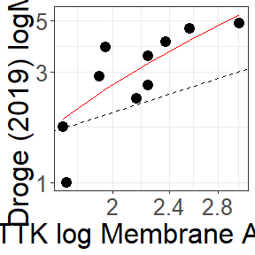

```r
fig.logma  <- ggplot(data=logma.table) +
  geom_point(aes(
    x=HTTK.logMA,
    y=logMA
    ),
    size=POINT.SIZE) +
  geom_abline(slope=1,intercept=0,linetype="dashed")+
  geom_line(aes(x=HTTK.logMA,
    y=Fit.logMA), color="red")+
  ylab("Droge (2019) logMA") +
  xlab("HTTK log Membrane Affinity") +
  scale_x_log10(label=scientific_10)+
  scale_y_log10(label=scientific_10)+
  theme_bw()  +
  theme( text  = element_text(size=FONT.SIZE))

print(fig.logma)
```

```r
half.lives <- NULL
for (this.chem in new.pfas)
{
  new.row <- data.frame(DTXSID=this.chem,
                        Human.HL=calc_half_life(
                          dtxsid=this.chem,
                          species="human",
                          model="sumclearances",
                          class.exclude=FALSE,
                          suppress.messages=TRUE),
                        Rat.HL=calc_half_life(
                          dtxsid=this.chem,
                          species="rat",
                          model="sumclearances",
                          default.to.human=TRUE,
                          class.exclude=FALSE,
                          suppress.messages=TRUE))
  new.row$Type <- "HTTK"
  half.lives <- rbind(half.lives, new.row)
  param.human <- try(parameterize_pfas1comp(dtxsid=this.chem,
                                  species="human",
                                  suppress.messages=TRUE))
  param.rat <- try(parameterize_pfas1comp(dtxsid=this.chem,
                                  species="rat",
                                  suppress.messages=TRUE))
  if ("kelim" %in% names(param.human) &
      "kelim" %in% names(param.rat))
    new.row <- data.frame(DTXSID=this.chem,
                        Human.HL=log(2)/param.human$kelim,
                        Rat.HL=log(2)/param.rat$kelim)
  new.row$Type <- "ML"
  half.lives <- rbind(half.lives, new.row)
}
```

[output not shown]

[output cut: 1259 more lines]

[output not shown]

```r
half.lives$Ratio <- half.lives$Human.HL / half.lives$Rat.HL
```

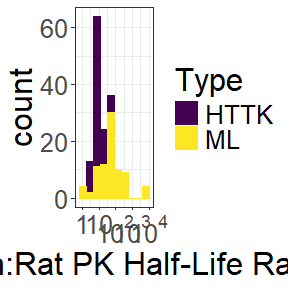

```r
fig.species.scaling <- ggplot(data=half.lives) +
  geom_histogram(aes(
    x=Ratio,
    colour=Type,
    fill=Type),
    bins=10) +
  xlab("Human:Rat PK Half-Life Ratio") +
  scale_x_log10(label=scientific_10)+
  theme_bw()  +
  theme( text  = element_text(size=FONT.SIZE))+
        scale_fill_viridis(discrete=2)+
        scale_color_viridis(discrete=2)

print(fig.species.scaling)
```

```r
LOC.WD <- "c:/users/jwambaug/"
wallis <- as.data.frame(read_excel(paste0(LOC.WD,"Wallis-2023-PFASHL.xlsx")))
wallis$HL.Low <- sapply(wallis[,4],function(x) as.numeric(strsplit(x,", ")[[1]][1]))
wallis$HL.High <- sapply(wallis[,4],function(x) as.numeric(strsplit(x,", ")[[1]][2]))
for (this.chem in wallis$DTXSID)
{
  param.human <- try(parameterize_pfas1comp(dtxsid=this.chem,
                                  species="human",
                                  suppress.messages=TRUE,
                                  restrict.doa="none"))
  if ("kelim" %in% names(param.human))
    wallis[wallis$DTXSID == this.chem, "HL.ML"] <- log(2)/param.human$kelim/24
}
```

[output not shown]

```r
wallis[wallis$DTXSID=="DTXSID90723993","HL.ML"] <- 29000/24
wallis[wallis$DTXSID=="DTXSID50723994","HL.ML"] <- 29000/24
wallis[wallis$DTXSID=="DTXSID20892348","HL.ML"] <- 53/24
for (this.col in c("HL.Low","HL.High"))
{
  new.col <- paste0(this.col,".Class")
    wallis[, new.col] <- 4
  wallis[wallis[, this.col] < 60,
       new.col] <- 3
  wallis[wallis[, this.col] < 7,
       new.col] <- 2
  wallis[wallis[, this.col] < 0.5,
       new.col] <- 1
}
```

[figure not shown]

```r
wallis$HL.ML.jitter <- wallis$HL.ML*(1.0+runif(dim(wallis)[1],-0.5,0.5))

wallis.fig <- ggplot(data=wallis) +
  geom_segment(aes(
    x=HL.ML.jitter,
    xend=HL.ML.jitter,
    y=HL.Low,
    yend=HL.High,
    colour=Status),
    position = "jitter",
    linewidth=2) +
    geom_abline(slope=1,intercept=0,linetype="dashed")+
  xlab("Machine Learning Half-Life Prediction") +
  ylab("Wallis et al. (2023) Estimate") +
  scale_x_log10(label=scientific_10)+
  scale_y_log10(label=scientific_10)+
  theme_bw()  +
  theme( text  = element_text(size=FONT.SIZE))+
        scale_color_viridis(discrete=2)

print(wallis.fig)
```

```r
tiff(file = paste0(LOC.WD,"WallisComparison.tiff"),
     width=12,
     height=11,
     units="in",
     res=300)
print(wallis.fig)
dev.off()
```

```r
subset(wallis, is.na(HL.ML))
```

```
#>  [1] compound
#>  [2] literature half-life (days)
#>  [3] Model 1 predicted half-life 95% CI (days)
#>  [4] Model 2 predicted half-life 95% CI (days)
#>  [5] Name Used in Paper or Google
#>  [6] DTXSID
#>  [7] PREFERRED_NAME
#>  [8] CASRN
#>  [9] Status
#> [10] HL.Low
#> [11] HL.High
#> [12] HL.ML
#> [13] HL.Low.Class
#> [14] HL.High.Class
#> [15] HL.ML.jitter
#> <0 rows> (or 0-length row.names)
```